# Group 4 Assignment 4

# Data Exploration

The first thing we will do for this assignment is explore the dataset provided. This dataset is a mental health dataset from a real-life research project. All identifying information of the dataset was removed and the data dictionary provides an explanation of each of the variables. The data contains 54 variables with 175 observations per variable. Every variable in the dataset is imported in as numeric features with the exception of `Initial` which will not be used as part of any exploration or analysis.

```r
ADHD_data<-read_csv("ADHD_data.csv")
names(ADHD_data)<-str_replace_all(names(ADHD_data)," +","_")
names(ADHD_data)<-str_replace_all(names(ADHD_data),"-","_")

psych::describe(ADHD_data) %>%
  kable() %>%
  kable_styling() %>%
  scroll_box(height = "200px")
```

|  | vars | n | mean | sd | median | trimmed | mad | min | max | range | skew | kurtosis | se |
| --- | --- | --- | --- | --- | --- | --- | --- | --- | --- | --- | --- | --- | --- |
| Initial* | 1 | 175 | 53.7371429 | 31.8036278 | 54 | 53.5248227 | 42.9954 | 1 | 108 | 107 | 0.0230736 | -1.2663915 | 2.4041283 |
| Age | 2 | 175 | 39.4742857 | 11.1709893 | 42 | 39.5460993 | 13.3434 | 18 | 69 | 51 | -0.1040228 | -0.9579297 | 0.8444474 |
| Sex | 3 | 175 | 1.4342857 | 0.4970851 | 1 | 1.4184397 | 0.0000 | 1 | 2 | 1 | 0.2628877 | -1.9418888 | 0.0375761 |
| Race | 4 | 175 | 1.6400000 | 0.6878252 | 2 | 1.6099291 | 0.0000 | 1 | 6 | 5 | 2.7054966 | 15.8898553 | 0.0519947 |
| ADHD_Q1 | 5 | 175 | 1.6971429 | 1.2886520 | 2 | 1.6241135 | 1.4826 | 0 | 4 | 4 | 0.2520512 | -1.0213992 | 0.0974129 |
| ADHD_Q2 | 6 | 175 | 1.9142857 | 1.2542211 | 2 | 1.8936170 | 1.4826 | 0 | 4 | 4 | 0.1433478 | -0.9958406 | 0.0948102 |
| ADHD_Q3 | 7 | 175 | 1.9085714 | 1.2697568 | 2 | 1.8865248 | 1.4826 | 0 | 4 | 4 | 0.1537456 | -1.0214282 | 0.0959846 |
| ADHD_Q4 | 8 | 175 | 2.1028571 | 1.3393869 | 2 | 2.1276596 | 1.4826 | 0 | 4 | 4 | -0.0582904 | -1.1174516 | 0.1012481 |
| ADHD_Q5 | 9 | 175 | 2.2571429 | 1.4412410 | 3 | 2.3120567 | 1.4826 | 0 | 5 | 5 | -0.3145486 | -1.2010248 | 0.1089476 |
| ADHD_Q6 | 10 | 175 | 1.9085714 | 1.3054641 | 2 | 1.8865248 | 1.4826 | 0 | 4 | 4 | -0.0784150 | -1.1428327 | 0.0986838 |
| ADHD_Q7 | 11 | 175 | 1.8285714 | 1.1862651 | 2 | 1.7872340 | 1.4826 | 0 | 4 | 4 | 0.3108433 | -0.7349764 | 0.0896732 |
| ADHD_Q8 | 12 | 175 | 2.1371429 | 1.2925707 | 2 | 2.1702128 | 1.4826 | 0 | 4 | 4 | -0.0795331 | -1.1297030 | 0.0977092 |
| ADHD_Q9 | 13 | 175 | 1.9085714 | 1.3186050 | 2 | 1.8865248 | 1.4826 | 0 | 4 | 4 | 0.0625975 | -1.1892099 | 0.0996772 |
| ADHD_Q10 | 14 | 175 | 2.1200000 | 1.2328828 | 2 | 2.1347518 | 1.4826 | 0 | 4 | 4 | 0.0838087 | -1.0339337 | 0.0931972 |
| ADHD_Q11 | 15 | 175 | 2.2742857 | 1.2383579 | 2 | 2.3333333 | 1.4826 | 0 | 4 | 4 | -0.1840841 | -0.9645685 | 0.0936111 |
| ADHD_Q12 | 16 | 175 | 1.2914286 | 1.2085356 | 1 | 1.1489362 | 1.4826 | 0 | 4 | 4 | 0.7331850 | -0.3474905 | 0.0913567 |
| ADHD_Q13 | 17 | 175 | 2.3657143 | 1.2331491 | 2 | 2.4397163 | 1.4826 | 0 | 4 | 4 | -0.2951539 | -0.8989614 | 0.0932173 |
| ADHD_Q14 | 18 | 175 | 2.2457143 | 1.3485503 | 2 | 2.3049645 | 1.4826 | 0 | 4 | 4 | -0.3095518 | -1.0816090 | 0.1019408 |
| ADHD_Q15 | 19 | 175 | 1.6342857 | 1.3949710 | 1 | 1.5460993 | 1.4826 | 0 | 4 | 4 | 0.3369081 | -1.1751486 | 0.1054499 |
| ADHD_Q16 | 20 | 175 | 1.7028571 | 1.3782977 | 1 | 1.6312057 | 1.4826 | 0 | 4 | 4 | 0.4086568 | -1.0491196 | 0.1041895 |
| ADHD_Q17 | 21 | 175 | 1.5257143 | 1.2857179 | 1 | 1.4113475 | 1.4826 | 0 | 4 | 4 | 0.4111746 | -0.8836476 | 0.0971911 |
| ADHD_Q18 | 22 | 175 | 1.4742857 | 1.3034752 | 1 | 1.3475177 | 1.4826 | 0 | 4 | 4 | 0.5668291 | -0.7862289 | 0.0985335 |
| ADHD_Total | 23 | 175 | 34.3200000 | 16.6953913 | 33 | 34.1985816 | 19.2738 | 0 | 72 | 72 | 0.0533291 | -0.7026800 | 1.2620530 |
| MD_Q1a | 24 | 175 | 0.5485714 | 0.4990632 | 1 | 0.5602837 | 0.0000 | 0 | 1 | 1 | -0.1935381 | -1.9737236 | 0.0377256 |
| MD_Q1b | 25 | 175 | 0.5714286 | 0.4962917 | 1 | 0.5886525 | 0.0000 | 0 | 1 | 1 | -0.2862043 | -1.9290122 | 0.0375161 |
| MD_Q1c | 26 | 175 | 0.5428571 | 0.4995893 | 1 | 0.5531915 | 0.0000 | 0 | 1 | 1 | -0.1705891 | -1.9821280 | 0.0377654 |
| MD_Q1d | 27 | 175 | 0.5828571 | 0.4945018 | 1 | 0.6028369 | 0.0000 | 0 | 1 | 1 | -0.3331987 | -1.8997365 | 0.0373808 |
| MD_Q1e | 28 | 175 | 0.5542857 | 0.4984706 | 1 | 0.5673759 | 0.0000 | 0 | 1 | 1 | -0.2165645 | -1.9642262 | 0.0376808 |
| MD_Q1f | 29 | 175 | 0.6971429 | 0.4608124 | 1 | 0.7446809 | 0.0000 | 0 | 1 | 1 | -0.8507423 | -1.2834739 | 0.0348341 |
| MD_Q1g | 30 | 175 | 0.7200000 | 0.4502873 | 1 | 0.7730496 | 0.0000 | 0 | 1 | 1 | -0.9715703 | -1.0620222 | 0.0340385 |
| MD_Q1h | 31 | 175 | 0.5600000 | 0.4978113 | 1 | 0.5744681 | 0.0000 | 0 | 1 | 1 | -0.2396777 | -1.9536204 | 0.0376310 |
| MD_Q1i | 32 | 175 | 0.5885714 | 0.4935046 | 1 | 0.6099291 | 0.0000 | 0 | 1 | 1 | -0.3568976 | -1.8832880 | 0.0373054 |
| MD_Q1j | 33 | 175 | 0.3885714 | 0.4888242 | 0 | 0.3617021 | 0.0000 | 0 | 1 | 1 | 0.4532993 | -1.8047347 | 0.0369516 |
| MD_Q1k | 34 | 175 | 0.4857143 | 0.5012300 | 0 | 0.4822695 | 0.0000 | 0 | 1 | 1 | 0.0566769 | -2.0081652 | 0.0378894 |
| MD_Q1L | 35 | 175 | 0.5828571 | 0.4945018 | 1 | 0.6028369 | 0.0000 | 0 | 1 | 1 | -0.3331987 | -1.8997365 | 0.0373808 |
| MD_Q1m | 36 | 175 | 0.4914286 | 0.5013610 | 0 | 0.4893617 | 0.0000 | 0 | 1 | 1 | 0.0339973 | -2.0102335 | 0.0378993 |
| MD_Q2 | 37 | 175 | 0.7200000 | 0.4502873 | 1 | 0.7730496 | 0.0000 | 0 | 1 | 1 | -0.9715703 | -1.0620222 | 0.0340385 |
| MD_Q3 | 38 | 175 | 2.0057143 | 1.0747742 | 2 | 2.1276596 | 1.4826 | 0 | 3 | 3 | -0.7016577 | -0.8397355 | 0.0812453 |
| MD_TOTAL | 39 | 175 | 10.0228571 | 4.8125247 | 11 | 10.3404255 | 4.4478 | 0 | 17 | 17 | -0.4793695 | -0.7287448 | 0.3637927 |
| Alcohol | 40 | 171 | 1.3450292 | 1.3946184 | 1 | 1.3065693 | 1.4826 | 0 | 3 | 3 | 0.2279514 | -1.8274542 | 0.1066491 |
| THC | 41 | 171 | 0.8070175 | 1.2663788 | 0 | 0.6350365 | 0.0000 | 0 | 3 | 3 | 1.0540839 | -0.7707323 | 0.0968424 |
| Cocaine | 42 | 171 | 1.0935673 | 1.3900972 | 0 | 0.9927007 | 0.0000 | 0 | 3 | 3 | 0.5652679 | -1.6099919 | 0.1063034 |
| Stimulants | 43 | 171 | 0.1228070 | 0.5336944 | 0 | 0.0000000 | 0.0000 | 0 | 3 | 3 | 4.7258476 | 21.9576904 | 0.0408126 |
| Sedative_hypnotics | 44 | 171 | 0.1228070 | 0.5446048 | 0 | 0.0000000 | 0.0000 | 0 | 3 | 3 | 4.6380203 | 20.7638045 | 0.0416470 |
| Opioids | 45 | 171 | 0.3918129 | 0.9903907 | 0 | 0.1167883 | 0.0000 | 0 | 3 | 3 | 2.1955022 | 2.9310366 | 0.0757371 |
| Court_order | 46 | 170 | 0.0882353 | 0.2844747 | 0 | 0.0000000 | 0.0000 | 0 | 1 | 1 | 2.8778837 | 6.3194914 | 0.0218182 |
| Education | 47 | 166 | 11.9036145 | 2.1720788 | 12 | 11.8283582 | 1.4826 | 6 | 19 | 13 | 0.3663734 | 1.3726744 | 0.1685860 |
| Hx_of_Violence | 48 | 164 | 0.2439024 | 0.4307498 | 0 | 0.1818182 | 0.0000 | 0 | 1 | 1 | 1.1818275 | -0.6068729 | 0.0336359 |
| Disorderly_Conduct | 49 | 164 | 0.7256098 | 0.4475731 | 1 | 0.7803030 | 0.0000 | 0 | 1 | 1 | -1.0019998 | -1.0019949 | 0.0349496 |
| Suicide | 50 | 162 | 0.3024691 | 0.4607516 | 0 | 0.2538462 | 0.0000 | 0 | 1 | 1 | 0.8521362 | -1.2816613 | 0.0362001 |
| Abuse | 51 | 161 | 1.3291925 | 2.1236066 | 0 | 0.8837209 | 0.0000 | 0 | 7 | 7 | 1.4674814 | 0.8629422 | 0.1673636 |
| Non_subst_Dx | 52 | 153 | 0.4379085 | 0.6769714 | 0 | 0.3008130 | 0.0000 | 0 | 2 | 2 | 1.2353022 | 0.1900950 | 0.0547299 |
| Subst_Dx | 53 | 152 | 1.1381579 | 0.9282137 | 1 | 1.0573770 | 1.4826 | 0 | 3 | 3 | 0.4168892 | -0.7130819 | 0.0752881 |
| Psych_meds. | 54 | 57 | 0.9649123 | 0.8010019 | 1 | 0.9574468 | 1.4826 | 0 | 2 | 2 | 0.0609190 | -1.4663999 | 0.1060953 |

```r
dfMeta <- data.frame(missing = colSums(is.na(ADHD_data)),
                     dtype = sapply(ADHD_data, class),
                     num_of_unique = sapply(ADHD_data, function(x) length(unique(x)))) %>%
    tibble::rownames_to_column() %>%
    dplyr::select(columns = rowname, dtype, missing, num_of_unique)

dfMeta %>%
  kable() %>%
  kable_styling() %>%
  scroll_box(height = "200px")
```

| columns | dtype | missing | num_of_unique |
| --- | --- | --- | --- |
| Initial | character | 0 | 108 |
| Age | numeric | 0 | 42 |
| Sex | numeric | 0 | 2 |
| Race | numeric | 0 | 4 |
| ADHD_Q1 | numeric | 0 | 5 |
| ADHD_Q2 | numeric | 0 | 5 |
| ADHD_Q3 | numeric | 0 | 5 |
| ADHD_Q4 | numeric | 0 | 5 |
| ADHD_Q5 | numeric | 0 | 6 |
| ADHD_Q6 | numeric | 0 | 5 |
| ADHD_Q7 | numeric | 0 | 5 |
| ADHD_Q8 | numeric | 0 | 5 |
| ADHD_Q9 | numeric | 0 | 5 |
| ADHD_Q10 | numeric | 0 | 5 |
| ADHD_Q11 | numeric | 0 | 5 |
| ADHD_Q12 | numeric | 0 | 5 |
| ADHD_Q13 | numeric | 0 | 5 |
| ADHD_Q14 | numeric | 0 | 5 |
| ADHD_Q15 | numeric | 0 | 5 |
| ADHD_Q16 | numeric | 0 | 5 |
| ADHD_Q17 | numeric | 0 | 5 |
| ADHD_Q18 | numeric | 0 | 5 |
| ADHD_Total | numeric | 0 | 62 |
| MD_Q1a | numeric | 0 | 2 |
| MD_Q1b | numeric | 0 | 2 |
| MD_Q1c | numeric | 0 | 2 |
| MD_Q1d | numeric | 0 | 2 |
| MD_Q1e | numeric | 0 | 2 |
| MD_Q1f | numeric | 0 | 2 |
| MD_Q1g | numeric | 0 | 2 |
| MD_Q1h | numeric | 0 | 2 |
| MD_Q1i | numeric | 0 | 2 |
| MD_Q1j | numeric | 0 | 2 |
| MD_Q1k | numeric | 0 | 2 |
| MD_Q1L | numeric | 0 | 2 |
| MD_Q1m | numeric | 0 | 2 |
| MD_Q2 | numeric | 0 | 2 |
| MD_Q3 | numeric | 0 | 4 |
| MD_TOTAL | numeric | 0 | 18 |
| Alcohol | numeric | 4 | 5 |
| THC | numeric | 4 | 5 |
| Cocaine | numeric | 4 | 5 |
| Stimulants | numeric | 4 | 4 |
| Sedative_hypnotics | numeric | 4 | 5 |
| Opioids | numeric | 4 | 4 |
| Court_order | numeric | 5 | 3 |
| Education | numeric | 9 | 15 |
| Hx_of_Violence | numeric | 11 | 3 |
| Disorderly_Conduct | numeric | 11 | 3 |
| Suicide | numeric | 13 | 3 |
| Abuse | numeric | 14 | 9 |
| Non_subst_Dx | numeric | 22 | 4 |
| Subst_Dx | numeric | 23 | 5 |
| Psych_meds. | numeric | 118 | 4 |

After observing the data’s structure, the next step was to plot the data to assess how this data is portrayed and what observations we can make about the distributions involved in the dataset. Based on the histrograms plotted below, we can note that there are many observations although numeric, behave as categorical features and this will need to be assessed when performing the kmeans clustering analysis. There does not seem to be any clear distinguishable outliers however there does seem to be some features that experience low variance such `Stimulants` where majority of the recorded observations are 0.

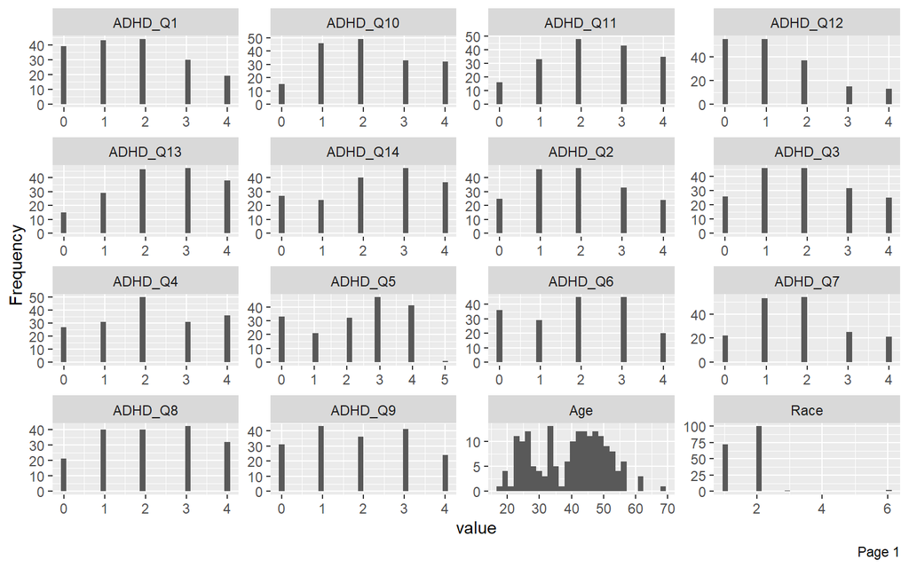

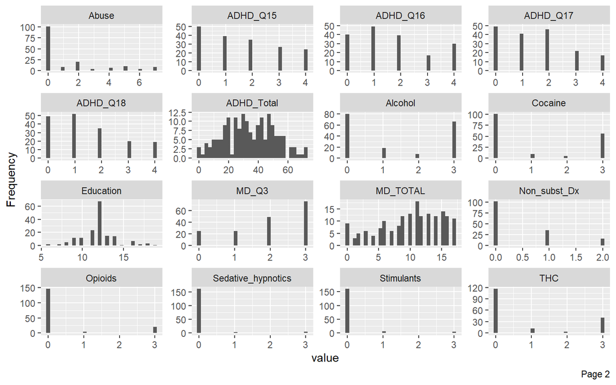

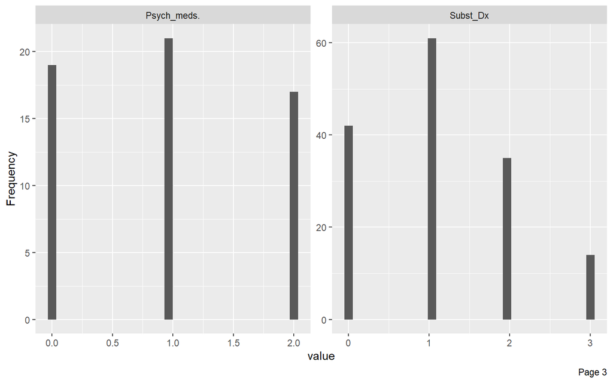

```r
plot_histogram(ADHD_data)+theme_bw()
```

Assessing correlations will be important for the models to come because Kmeans, and PCA are particularly sensitive to multi-colinearity and in order to reduce noise and complexity of the dataset prior to modeling, multi-colinearity (if it exists) should be addressed. The dataset was assessed for pairwise spearman correlations which measures data for it’s monotonicity providing a regression coefficient that defines both linear and non-linear trends. the table below shows we do exhibit correlations particularly amongst features that are directly related such as the `ADHDQ#` to the `ADHD_Total`. Highest measured spearman rank was around 0.79.

```r
NumericADHD<-ADHD_data %>%
  select(-Initial)

ADHD_cors<-
  bind_rows(
    #pearson correlation of numeric features
    NumericADHD %>%
      cor(method = "pearson", use = "pairwise.complete.obs") %>% as.data.frame() %>%
      rownames_to_column(var = "x") %>%
      pivot_longer(cols = -x, names_to = "y", values_to = "correlation") %>%
      mutate(cor_type = "pearson"),
    #spearman (monotonic) correlations of numeric features
    NumericADHD %>%
      cor(method = "spearman", use = "pairwise.complete.obs") %>% as.data.frame() %>%
      rownames_to_column(var = "x") %>%
      pivot_longer(cols = -x, names_to = "y", values_to = "correlation") %>%
      mutate(cor_type = "spearman")
  )

ADHD_cors %>%
  filter(!(x ==y)) %>%
  filter(cor_type=="spearman") %>%
  distinct(correlation,.keep_all = T) %>%
  arrange(-correlation) %>% #top_n(10, correlation) %>%
  distinct(x, .keep_all = T) %>%
  kable() %>%
  kable_styling(position = "center") %>%
  scroll_box(height = "200px")
```

| x | y | correlation | cor_type |
| --- | --- | --- | --- |
| ADHD_Q9 | ADHD_Total | 0.7944898 | spearman |
| ADHD_Q8 | ADHD_Total | 0.7941556 | spearman |
| ADHD_Q10 | ADHD_Total | 0.7872177 | spearman |
| ADHD_Q13 | ADHD_Total | 0.7667445 | spearman |
| ADHD_Q5 | ADHD_Total | 0.7457331 | spearman |
| ADHD_Q4 | ADHD_Total | 0.7283871 | spearman |
| ADHD_Q7 | ADHD_Total | 0.7261428 | spearman |
| ADHD_Q11 | ADHD_Total | 0.7251387 | spearman |
| ADHD_Q14 | ADHD_Total | 0.7195527 | spearman |
| ADHD_Q18 | ADHD_Total | 0.7099764 | spearman |
| ADHD_Q2 | ADHD_Total | 0.6996578 | spearman |
| ADHD_Q1 | ADHD_Total | 0.6892343 | spearman |
| MD_Q1a | MD_TOTAL | 0.6850615 | spearman |
| ADHD_Q12 | ADHD_Total | 0.6835530 | spearman |
| MD_Q1L | MD_TOTAL | 0.6780450 | spearman |
| MD_Q2 | MD_TOTAL | 0.6691259 | spearman |
| ADHD_Q16 | ADHD_Total | 0.6665018 | spearman |
| ADHD_Q3 | ADHD_Total | 0.6646760 | spearman |
| MD_Q1b | MD_TOTAL | 0.6465047 | spearman |
| ADHD_Q17 | ADHD_Total | 0.6405340 | spearman |
| ADHD_Q15 | ADHD_Total | 0.6385524 | spearman |
| ADHD_Q6 | ADHD_Total | 0.6379948 | spearman |
| MD_Q1e | MD_TOTAL | 0.6287386 | spearman |
| MD_Q1g | MD_TOTAL | 0.6203933 | spearman |
| MD_Q1h | MD_Q1i | 0.6157163 | spearman |
| ADHD_Total | MD_Q1g | 0.6137537 | spearman |
| MD_Q1f | MD_TOTAL | 0.6110345 | spearman |
| MD_Q1j | MD_TOTAL | 0.6049776 | spearman |
| MD_Q1m | MD_TOTAL | 0.5992611 | spearman |
| MD_Q1i | MD_TOTAL | 0.5834584 | spearman |
| MD_Q1d | MD_TOTAL | 0.5498626 | spearman |
| MD_Q3 | MD_TOTAL | 0.5307158 | spearman |
| MD_Q1k | MD_TOTAL | 0.5134463 | spearman |
| Non_subst_Dx | Psych_meds. | 0.5007790 | spearman |
| MD_Q1c | MD_TOTAL | 0.4700712 | spearman |
| Cocaine | Subst_Dx | 0.4297406 | spearman |
| Sedative_hypnotics | Opioids | 0.3797873 | spearman |
| Sex | Abuse | 0.3679372 | spearman |
| THC | Subst_Dx | 0.3561781 | spearman |
| Hx_of_Violence | Disorderly_Conduct | 0.3492625 | spearman |
| Alcohol | Subst_Dx | 0.3319289 | spearman |
| Suicide | Abuse | 0.3298665 | spearman |
| Abuse | Psych_meds. | 0.2763363 | spearman |
| Disorderly_Conduct | Subst_Dx | 0.2746133 | spearman |
| MD_TOTAL | Alcohol | 0.2743850 | spearman |
| Opioids | Subst_Dx | 0.2580600 | spearman |
| Race | Cocaine | 0.2513707 | spearman |
| Court_order | Disorderly_Conduct | 0.1878673 | spearman |
| Education | Non_subst_Dx | 0.1611136 | spearman |
| Age | Cocaine | 0.1492548 | spearman |
| Stimulants | Sedative_hypnotics | 0.1248315 | spearman |
| Subst_Dx | Psych_meds. | 0.0428331 | spearman |

Next, we want to assess any missing data within the dataset. The models presented here are also susceptible to missing data and this must be treated accordingly. The figure below displays a plot of missing data by percentage of observations in the dataset. It is clear that the feature `Psych_meds.` has a significant amount of features that are inappropriate to impute or include and thus this feature will be removed from the dataset prior to any models.

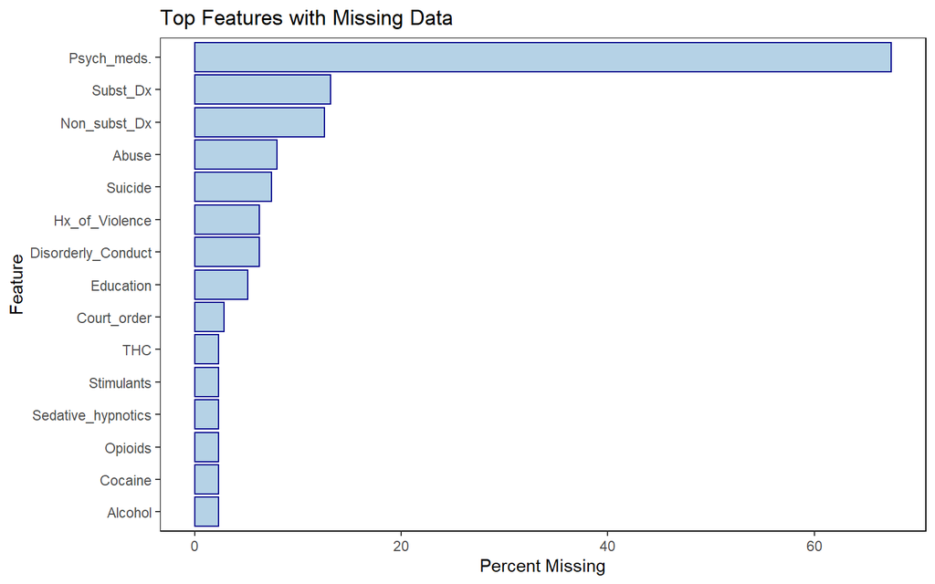

```r
ADHD_data %>%  naniar::miss_var_summary() %>%
  slice_max(n_miss, n = 10) %>%
  ggplot(aes( x = fct_reorder(variable, n_miss), y = pct_miss))+
  coord_flip()+
  geom_col(alpha = 0.5, fill = "skyblue3", color = "darkblue")+
  defaulttheme+
  labs(title = "Top Features with Missing Data",
       y = "Percent Missing",
       x = "Feature")
```